# duterte_news_analysis

## Data cleaning : Duterte and war on drugs

Now, we focus on news captions particularly about Duterte and drugs. We only obtain captions that both contain “Duterte” (or variations thereof) and “drugs” (or variations thereof). We also remove messages with words related to the COVID-19 pandemic, since these may discuss medical drugs.

```r
stripped_words <- compiled %>%
  mutate(stripped_text = tolower(str_replace_all(compiled$message, remove_expressions, " "))) %>%
  mutate(message = stripped_text) %>%
  filter(grepl("duterte|digong|rodrigo|rody|president|pangulo",message)) %>%
  filter(grepl("droga|drug|shabu",message)) %>%
  filter(!grepl("covid|pandemic|pandemya|vaccin",message))

compiled_words <- stripped_words %>%
  unnest_tokens(output = word,
                input = stripped_text) %>%
  anti_join(stopwords_merged, by = "word") %>%
  mutate(word = str_extract(word, "[a-z]+")) %>%
  drop_na(word) %>%
  anti_join(stopwords_merged, by = "word")
```

## Determining other stopwords

In order to further refine our topic model, we need to also remove the following words or phrases usually used in captions. Otherwise, the model may identify topics revolving around these words just because how often they are used.

1. Brand words (eg. “snstr” for SunStar, or “ThewRap” for Rappler)
2. Unique patterns or phrases used in reporting (For example, some of Philippine Star’s news started with “Today’s front news”, while some in Rappler’s ended with “Full story”)
3. Names of reporters

Although it is manually intensive to get an exhaustive list of the above, we expect that these words are unique for a given outlet. We can determine the top 10 words per news outlet based on TF-IDF scores.

```r
################################
## TF-IDF - Per News Outlet
################################

compiled_freq_news <- compiled_words %>%
  count(word, from.name, name = "freq") %>%
  group_by(from.name) %>%
  mutate(proportion = round(freq/sum(freq),5)) %>%
  arrange(from.name, desc(proportion)) %>%
  ungroup()

compiled_tf_idf_news <- compiled_freq_news %>%
  group_by(from.name, word) %>%
  summarize(n = sum(freq)) %>%
  bind_tf_idf(word, from.name, n) %>%
  arrange(from.name, desc(tf_idf)) %>%
  ungroup()
compiled_tf_idf_news %>%
  group_by(from.name) %>%
  head(10)
```

| from.name | word | n | tf | idf | tf_idf |
| --- | --- | --- | --- | --- | --- |
| ABS-CBN News | pangulong | 12 | 0.012182741 | 1.0986123 | 0.013384109 |
| ABS-CBN News | roque | 14 | 0.014213198 | 0.8109302 | 0.011525912 |
| ABS-CBN News | padilla | 6 | 0.006091371 | 1.5040774 | 0.009161893 |
| ABS-CBN News | enemy | 4 | 0.004060914 | 2.1972246 | 0.008922739 |
| ABS-CBN News | droga | 7 | 0.007106599 | 1.0986123 | 0.007807397 |
| ABS-CBN News | posibleng | 3 | 0.003045685 | 2.1972246 | 0.006692055 |
| ABS-CBN News | kontra | 5 | 0.005076142 | 1.0986123 | 0.005576712 |
| ABS-CBN News | palace | 6 | 0.006091371 | 0.8109302 | 0.004939676 |
| ABS-CBN News | administrasyon | 3 | 0.003045685 | 1.5040774 | 0.004580946 |
| ABS-CBN News | basahin | 3 | 0.003045685 | 1.5040774 | 0.004580946 |

By looking at the words with high TF-IDF scores and determining how they are used in news captions, we identify the following words that also need to be removed:

```r
################################
## Stopwords per News Outlet
################################

outlet_stopwords <- tibble(word = c(
  "gma","jessica","soho","kapuso","bulletin", "befullyinformed", "manilabulletin",
  "headline", "instagram", "newsstand", "copy", "follow", "grab","twitter",
  "website","favorite","mbrundown","rappler", "story", "thewrap",
  "pia","cnn","cnnphnewsnight","highlights","hontiveros","headlines","happening",
  "tonight", "lxc", "inqnews", "inquirer", "icymi",
  "julliane","net","read","thephilippinestar","page","front","charles","cignaltv",
  "lejano","weareonenews","newsroom","onenewsroom","december","september", "thursday",
  "friday", "tuesday","snstr", "sunstarpilipinas", "facebook","subscribe","breaking",
  "youtube", "ruth"),
lexicon = "news_stopwords")

stopwords_merged_new <- rbind(stopwords_tl, stop_words, new_stopwords, outlet_stopwords)
```

## Topic Modelling: Duterte and war on drugs

We perform topic modelling to identify topics in our corpus. Just like the earlier topic model, we consider all relevant captions made by one outlet for a year as one document.

```r
################################
## Creating DTM object
################################

compiled_dtm <- stripped_words %>%
  mutate(document = paste0(from.name,"_",year)) %>%
  unnest_tokens(word, stripped_text) %>%
  anti_join(stopwords_merged_new, by = "word") %>%
  mutate(word = str_extract(word, "[a-z]+")) %>%
  drop_na(word) %>%
  anti_join(stopwords_merged_new, by = "word") %>%
  count(document, word, name = "freq", sort = TRUE) %>%
  mutate(nchar = nchar(word)) %>%
  filter(nchar > 2) %>%
  cast_dtm(document, word, freq)


################################
## Finetuning Controls
################################

control_list_gibbs <- list(
  burnin = 500,
  iter = 1000,
  seed = 0:10,
  nstart = 11,
  best = TRUE
)

###################################################
## Determining best model using log-likehood
###################################################

mod_log_lik = numeric(25)
for(i in 2:25){
  mod = LDA(x = compiled_dtm,
            k = i,
            method = "Gibbs",
            control = control_list_gibbs)
  mod_log_lik[i] = logLik(mod)
}

tibble(k = 2:25, score = mod_log_lik[-1]) %>%
  top_n(3, score) %>%
  arrange(-score) ## Result : 20 topics
```

| k | score |
| --- | --- |
| 20 | -90115.91 |
| 15 | -90275.59 |
| 18 | -90302.84 |

```r
###################################################
## Creating LDA model
###################################################


lda_model_log <- LDA(x = compiled_dtm,
                     k = 20,
                     method = "Gibbs",
                     control = control_list_gibbs)


lda_beta_log <- tidy(lda_model_log, matrix = "beta")

lda_beta_log %>%
  filter(topic == 4) %>% ## Change topic number to see words per table
  select(word = term, freq = beta) %>%
  arrange(desc(freq)) %>%
  print(n = 15) %>%
  wordcloud2(
    size = .5,
    gridSize = 10,
    shape = "diamond",
    color = "random-dark"
  )
```

| word | freq |
| --- | --- |
| country | 0.0091372079 |
| kill | 0.0091372079 |
| espinosa | 0.0076393050 |
| agency | 0.0061414020 |
| law | 0.0046434991 |
| support | 0.0046434991 |
| cocaine | 0.0046434991 |
| loan | 0.0046434991 |
| added | 0.0046434991 |
| assembly | 0.0046434991 |

[output cut: 990 more lines]

[interactive chart not shown]

We get the mean gammas of each topic to determine which specific topics to further discuss. The higher the mean, the more often it is being reported by outlets.

```r
###################################################
## Visualizing trends per year
###################################################

lda_gamma_log <- tidy(lda_model_log, matrix = "gamma")

lda_gamma_log %>% group_by(topic) %>% summarize(mean = mean(gamma)) %>% arrange(desc(mean))
```

| topic | mean |
| --- | --- |
| 12 | 0.23958176 |
| 1 | 0.06617414 |
| 3 | 0.06078197 |
| 20 | 0.05566157 |
| 5 | 0.05378282 |
| 13 | 0.04513103 |
| 16 | 0.03715828 |
| 7 | 0.03700350 |
| 18 | 0.03693069 |
| 6 | 0.03606633 |

[output cut: 10 more lines]

```r
lda_gamma_log %>%
  separate(document, c("from.name","year"), sep = "_") %>%
  select(from.name,year,topic,gamma) %>%
  filter(from.name == "GMA News") %>%
  filter(topic == 1) %>%
  arrange(year) %>%
  group_by(topic) %>%
  top_n(1,gamma) %>%
  ungroup()
```

| from.name | year | topic | gamma |
| --- | --- | --- | --- |
| GMA News | 2020 | 1 | 0.052 |

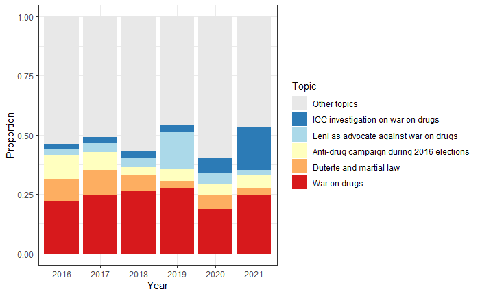

```r
wod_topics_per_year <- lda_gamma_log %>%
  separate(document, c("from.name","year"), sep = "_") %>%
  group_by(topic, year) %>%
  summarize(sum_gamma = sum(gamma)) %>%
  ungroup() %>%
  group_by(year) %>%
  mutate(prop = sum_gamma / sum(sum_gamma),
         topic_name = ifelse(topic == 12, "War on drugs",
                             ifelse(topic == 1, "Duterte and martial law",
                                    ifelse(topic == 3, "Anti-drug campaign during 2016 elections",
                                           ifelse(topic == 20, "Leni as advocate against war on drugs",
                                                  ifelse(topic == 5, "ICC investigation on war on drugs", "Other topics"))))))
ggplot(wod_topics_per_year, aes(x = year, y = prop, fill = factor(topic_name, levels = c("Other topics","ICC investigation on war on drugs","Leni as advocate against war on drugs","Anti-drug campaign during 2016 elections", "Duterte and martial law", "War on drugs")))) +
  geom_bar(stat="identity") + ylab("proportion") +
  scale_fill_manual("Topic", values = c("Other topics" = "#e8e8e8",
                                        "ICC investigation on war on drugs" = "#2c7bb6",
                                        "Leni as advocate against war on drugs" = "#abd9e9",                                             "Anti-drug campaign during 2016 elections" = "#ffffbf",
                                        "Duterte and martial law" = "#fdae61",
                                        "War on drugs" = "#d7191c")) +
  labs(x = "Year",
       y = "Proportion") +
  theme_bw()
```

The top 5 topics are (in decreasing order of means):

1. Topic 12: War on drugs in general
2. Topic 1: Duterte and martial law
3. Topic 3: Duterte’s anti-drug campaign during 2016 elections
4. Topic 20: Leni as advocate against war on drugs
5. Topic 5: ICC investigation on war on drugs

The share of each topic per year is visualized.